# Annotated code for `headache_ode.R`

Mathew Kiang

January 28, 2018

## Introduction

This is annotated code for the [`headache_ode.R`](https://raw.githubusercontent.com/mkiang/epi501_review/master/exercises/01_headaches/headache_ode.R) file. For convenience, the code from that file is shown below (with comments removed):

```r
library(deSolve)

times <- seq(0, 5000, by = 1)
yinit <- c(no_headache = 0.95, headache = 0.05)
parameters <- c(incidence = 0.02, recovery = 0.01,
                birth = 0.1, death = 0.2)

headache_model <- function(times, yinit, parameters) {
    with(as.list(c(yinit, parameters)), {

        dno_headache <- recovery*headache -
            incidence*no_headache - death*no_headache

        dheadache <- incidence*no_headache - recovery*headache -
            death*headache + birth*(headache+no_headache)

        comparts <- list(c(dno_headache, dheadache))

        return(comparts)
    })
}

result <- as.data.frame(ode(y = yinit, times = times,
                            func = headache_model, parms = parameters))

matplot(x = result[, "time"],
        y = result[, c("no_headache", "headache")],
        type = "l")
```

## Calling `deSolve`

```r
library(deSolve)
```

To solve differential equations, we use the `ode()` command. This command comes from the `deSolve` package, which means we must load the package before we can run the command.

All scripts that use `ode()` will have the `library(deSolve)` command at the top.

## Setting parameters

```r
times <- seq(0, 5000, by = 1)
yinit <- c(no_headache = 0.95, headache = 0.05)
parameters <- c(incidence = 0.02, recovery = 0.01,
                birth = 0.1, death = 0.2)
```

Like the discrete version, we need to set up initial values, parameter values, and a time sequence in order for `ode()` to work. Here we will use `seq(0, 5000, by = 1)` to specify that we want a vector of numbers from 0 to 5,000 in steps of 1.

- Unlike the discrete model, we won’t need to use integers and we could have done `seq(0, 5000, by = .0001)`. This would result in our epidemic curves being much smoother because `ode()` would evaluate our model at every .0001 units instead of every 1 unit. However, this would also result in much longer computation time. Choosing the length of your time sequence and the resolution will be a balancing act you’ll need to figure out throughout the course, but we will generally give you good starting values.
- We store all of our initial values in a variable called `yinit`. This is a named vector so that when we call `yinit` it will result in one element called `no_headache` and one called `headache`. When you add or remove compartments, you’ll need to adjust the `yinit` variable accordingly. There should always be as many elements as there are compartments.

```r
print(yinit)
```

```
no_headache    headache
       0.95        0.05
```

- Similarly, we will create a named vector to store all our parameters. When you modify your compartments with new parameters, you’ll need to specify the value of these parameters in this variable.

```r
print(parameters)
```

```
incidence  recovery     birth     death
     0.02      0.01      0.10      0.20
```

## Creating the model

Suppose this is our model of headaches:

$$\begin{align}
\frac{d N}{dt} &= \gamma P - \beta N - dN \\
\frac{d P}{dt} &= \beta N - \gamma P - dP + b(N+P)
\end{align}$$
What is this model saying about births and deaths?

Unlike the discrete model where we created our model inside of a `for()` loop, for ODE models, we will create a function that contains our models. This function will require three inputs: (1) a time sequence, (2) initial values of each compartment, and (3) the values of any parameters. In addition, we’re going to call this function `headache_model`.

```r
headache_model <- function(times, yinit, parameters) {
    with(as.list(c(yinit, parameters)), {
        dno_headache <- recovery*headache -
            incidence*no_headache - death*no_headache
        dheadache <- incidence*no_headache - recovery*headache -
            death*headache + birth*(headache+no_headache)
        comparts <- list(c(dno_headache, dheadache))
        return(comparts)
    })
}
```

You will only be expected to modify things inside of the `with` block. Specifically the `dno_headache`, `dheadache`, `comparts`, and `return()` lines. The `with()` command simply allows us to refer to the named elements in our `yinit` and `parameter` variables without the need to specify the object they are in. For example, instead of specifying `parameters$recovery * yinit$headache`, we can simply say `recovery*headache`.

In order for `ode()` to work, we must `return` a list of compartments. We create `comparts` which stores our compartments as a list using the `list()` command.

## Running our model

Now that we have our model (as a function), we can use `ode()` to solve it:

```r
result <- as.data.frame(ode(y = yinit, times = times,
                            func = headache_model, parms = parameters))
```

## Plot the results

Let’s see what `ode()` returned:

```r
head(result)
```

|  | time | no_headache | headache |
| --- | --- | --- | --- |
| 1 | 0 | 0.9500000 | 0.0500000 |
| 2 | 1 | 0.7632932 | 0.1415443 |
| 3 | 2 | 0.6141388 | 0.2045920 |
| 4 | 3 | 0.4949006 | 0.2459177 |
| 5 | 4 | 0.3994996 | 0.2708204 |
| 6 | 5 | 0.3231057 | 0.2834250 |

Note that `ode()` appended a column named `time` to our model in addition to the compartments.

We’ll use `matplot()` again to plot the results:

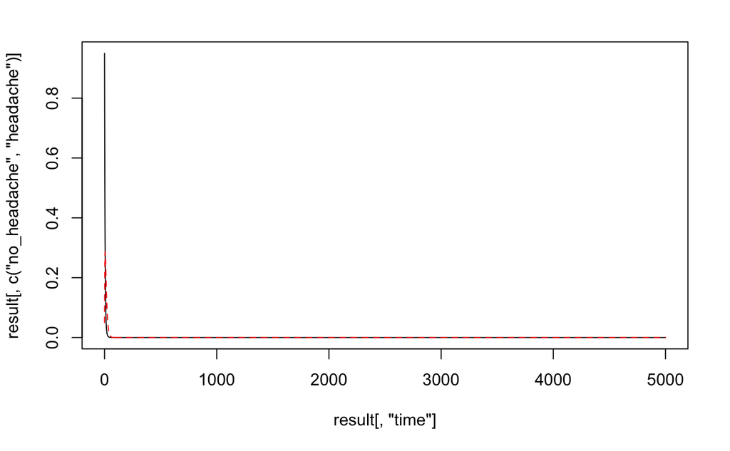

```r
matplot(x = result[, "time"],
        y = result[, c("no_headache", "headache")],
        type = "l")
```

Above, we referred to the columns by name, but we can also refer to them by position:

```r
matplot(x = result[, 1],
        y = result[, 2:3],
        type = "l")
```

### Trimming the x-axis

We can take a close look at the beginning of our model by specifying our x-axis limits with the `xlim` option. This option takes a vector of length 2 with the first element as the lower bound and the second element as the upper bound.

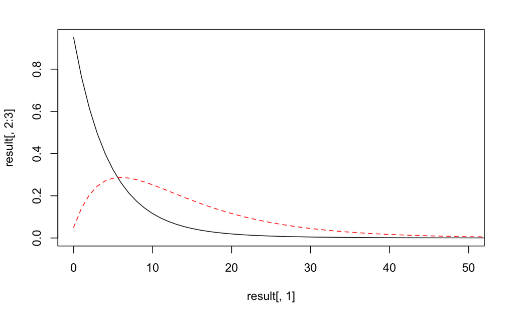

```r
matplot(x = result[, 1],
        y = result[, 2:3],
        type = "l",
        xlim = c(0, 50))
```

Try playing with other parameters.